# Geolocation analysis with Open Source Tools 2016 North American Ornithological Congress, Washington D.C.

2016-09-09

**Sponsored by:**

*Migrate Technology LLC.– www.migratetech.co.uk*

*The Cooper Ornithological Society*

*The National Science Foundation*

[figure not shown]

[figure not shown]

[figure not shown]

The following document outlines the steps for analyzing data from archival light-level geolocators (hereafter geolocators). Geolocators have been used to track individuals since the early 1990s but were restricted to large organisms because of their large size. Recently, with the miniturization of geolocators, researchers are now able to deploy geolocators on smaller and smaller species. Geolocators are devices that record ambient light levels every 2, 5, or 10 min depending on the model. The devices are attached to individuals which then migrate with the tag while it records ambient light-levels throughout the year. Once recovered, the data are downloaded and analyzed to determine twilight events (sunrise or sunset). See figure below created by Eli Bridge. Approximate geographic locations are then derived using the twilight events.

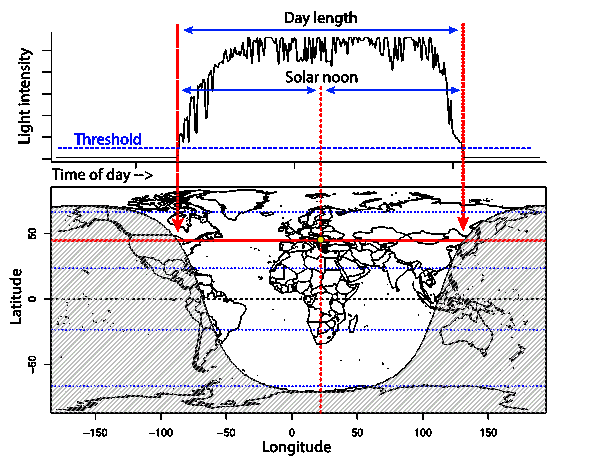

The code provided below was complied for the Geolocation analysis with Open Source Tools workshop at the North American Ornithological Congress meeting in Washington D.C.

## Getting started

In order to analyze light-level geolocator data in R you need a few packages. The workflow described below covers three popular open-source tools to analyze the light-level data. This document covers the how to analyze the data in `GeoLight`, `SGAT` and `FLightR` packages.

### Loading required packages

Be sure to acquire all required packages prior to running this analysis. See the [GetPackages.R script](https://github.com/Eli-S-Bridge/NAOC_Geos_2016/blob/master/GetPackages.R) to download all required packages if you haven’t done so already.

```r
# Check to make sure the required packages are installed on your machine
# If not, they will be installed

reqPackages <- c("devtools","digest","GeoLight","geosphere","raster","fields","forecast",
                  "circular","truncnorm","parallel","bit","rgdal","CircStats","Rcpp",
                  "RcppArmadillo","ggmap","ggsn","sp","maptools","rgeos","MASS")


get.packages <- reqPackages[!(reqPackages %in% installed.packages()[,"Package"])]

if(length(get.packages)>0){
  install.packages(get.packages,repos = "https://cloud.r-project.org/", dependencies = TRUE)
}

# Install necessary packages from Github using the devtools library #

library(devtools)
install_github("SWotherspoon/SGAT")
install_github("SLisovski/TwGeos")
install_github("SLisovski/GeoLight", ref = "Update_2.01", force = T)
install_github("eldarrak/FLightR")
```

```r
library(GeoLight)
library(TwGeos)
library(SGAT)
library(FLightR)
library(MASS)  #needed for fitting distributions
library(maptools)
```

## Which package should I use?

> **GeoLight** uses the threshold model to determine locations. Unlike the other packages described below, GeoLight doesn’t include a movement model and relies solely on the light-level data. GeoLight can be used with a variety of unit types i.e. `.lig` or `.lux` files.

> **SGAT** pronounced “tags backwards” also uses the threshold method but also includes a movement model and positions are estimated based on 1) the observed difference between known twilights and twilights recorded by the unit and 2) a movement model. The positions are estimated within a Bayesian framework. SGAT can used with `.lig` and `.lux`.  
> Go to SGAT

> **FLightR** uses a realistic movement model, the relationship between observed and expected light-levels and implements a particle filter to estimate locations. Of the three packages FLightR is the most computationally intense and most sophisticated. FLightR works best with `.lux` files but can be used with `.lig`. However, `.lig` files with lots of shading events that bounce from 0 to 64 dramatically don’t work well. More information about the underlying model can be found [here](http://onlinelibrary.wiley.com./doi/10.1111/jav.00891/abstract).  
> Go to FLightR

*Note* There are differences in the formats that are needed for each package. See Formats for more information.

## Getting data into R

There are a few functions to read light-level data into R. The type of file that you have will determine which function you use. If you have `.lig` from British Antarctic Survey or BioTrack you use the `readLig` found in the `TwGeos` package.

```r
#load the TwGeos package
library("TwGeos")

#read the data into a dataframe called d.lig
d.lig <- readLig("data/TRES.lig", skip = 0)

#reduce the dataframe to just Date and Light
d.lig <- subset(d.lig,select=c("Date","Light"))
```

Here are what the first few rows of data look like and the structure of the data.

```
##                  Date Light
## 1 2011-06-15 21:06:00    44
## 2 2011-06-15 21:07:59    64
## 3 2011-06-15 21:09:59    64
## 4 2011-06-15 21:11:59    64
## 5 2011-06-15 21:13:59    64
## 6 2011-06-15 21:15:59    64
```

```
## 'data.frame':    257621 obs. of  2 variables:
##  $ Date : POSIXct, format: "2011-06-15 21:06:00" "2011-06-15 21:07:59" ...
##  $ Light: int  44 64 64 64 64 64 64 64 64 64 ...
```

If you have a `.lux` file from Migrate Technology then you would use the `readMTlux` function which is also part of the `TwGeos` package.

```r
#read the data into a dataframe called d.lux
d.lux <- readMTlux("data/Godwit.lux")
```

```
##                  Date    Light
## 1 2013-05-09 18:25:17 1054.931
## 2 2013-05-09 18:30:17  945.917
## 3 2013-05-09 18:35:17  178.282
## 4 2013-05-09 18:40:17  114.691
## 5 2013-05-09 18:45:17   85.167
## 6 2013-05-09 18:50:17   91.980
```

```
## 'data.frame':    117354 obs. of  2 variables:
##  $ Date : POSIXct, format: "2013-05-09 18:25:17" "2013-05-09 18:30:17" ...
##  $ Light: num  1054.9 945.9 178.3 114.7 85.2 ...
```

Notice the difference in the `Light` measurement between the two types of tags. Migrate technology tags output light data in lux, and the values range from 0 to around 70,000 for full sunlight. Most other tags (including those from British Antarctic Survey or BioTrack) just have a somewhat arbitatry light intensity scale from 0 to around 64.

When working with Migrate technology tags, it is sometimes useful to log-transform the light values to reduce the range of values.

```r
#log transformation
d.lux$Light<- log(d.lux$Light)
head(d.lux)
```

```
##                  Date    Light
## 1 2013-05-09 18:25:17 6.961231
## 2 2013-05-09 18:30:17 6.852155
## 3 2013-05-09 18:35:17 5.183367
## 4 2013-05-09 18:40:17 4.742242
## 5 2013-05-09 18:45:17 4.444614
## 6 2013-05-09 18:50:17 4.521571
```

```r
str(d.lux)
```

```
## 'data.frame':    117354 obs. of  2 variables:
##  $ Date : POSIXct, format: "2013-05-09 18:25:17" "2013-05-09 18:30:17" ...
##  $ Light: num  6.96 6.85 5.18 4.74 4.44 ...
```

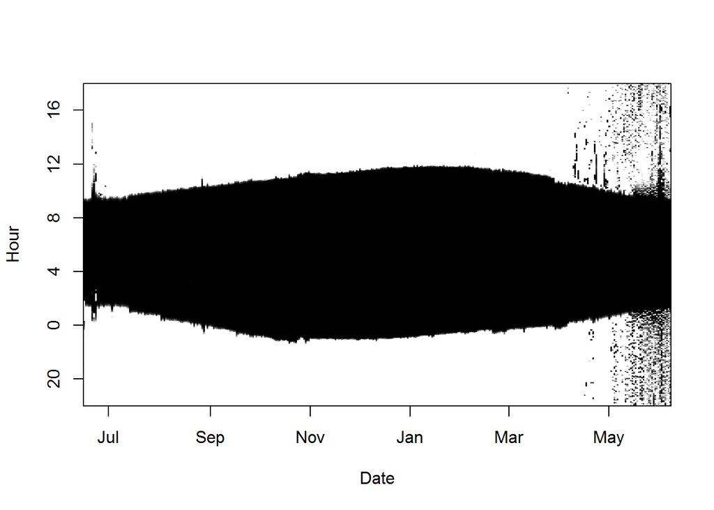

```r
lightImage( tagdata = d.lig, # light data
            offset = 18,     # adjusts the y-axis to put night (dark shades) in the middle
            zlim = c(0, 64), # y axis
            dt = 120)        # miniumn dark period
```